# Clase VIII: Algunas gráficas descriptivas

Jaime Mosquera.

10/6/2020

# Paquetes necesarios

```r
library(ggplot2)
library(car)
library(RcmdrMisc)
library(lubridate)
library(scales)
library(qcc)
library(agricolae)
```

# Ejemplo 1

## Préstamo de bicicletas

Los siguientes son datos correspondientes al número de bicicletas prestadas durante varias semanas por una estación del sistema de bicicletas públicas. En las filas se presentan las semanas de observación (no especificada):

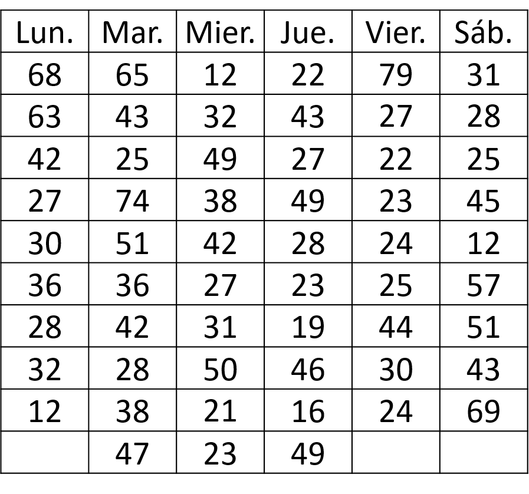

Vamos a tener en cuenta este ejemplo para los gráficos que vamos a aprender en esta sección.

## Boxplot

Tenga en cuenta que $Me = \tilde{X}$.

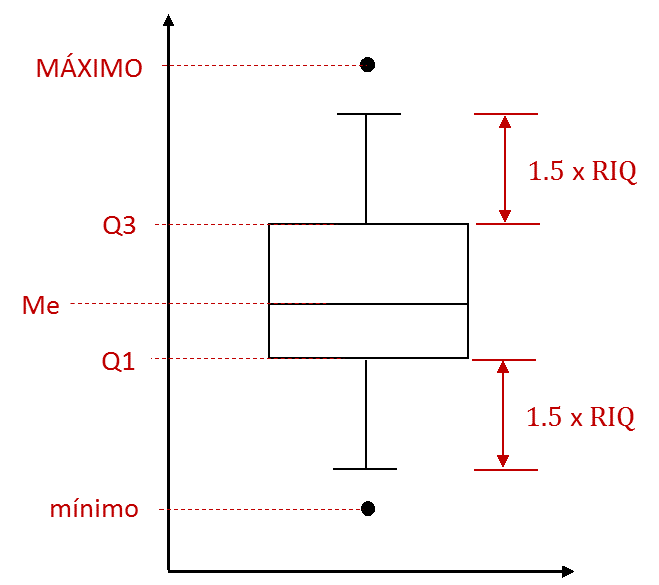

Hagamos un Boxplot sin variable de agrupación:

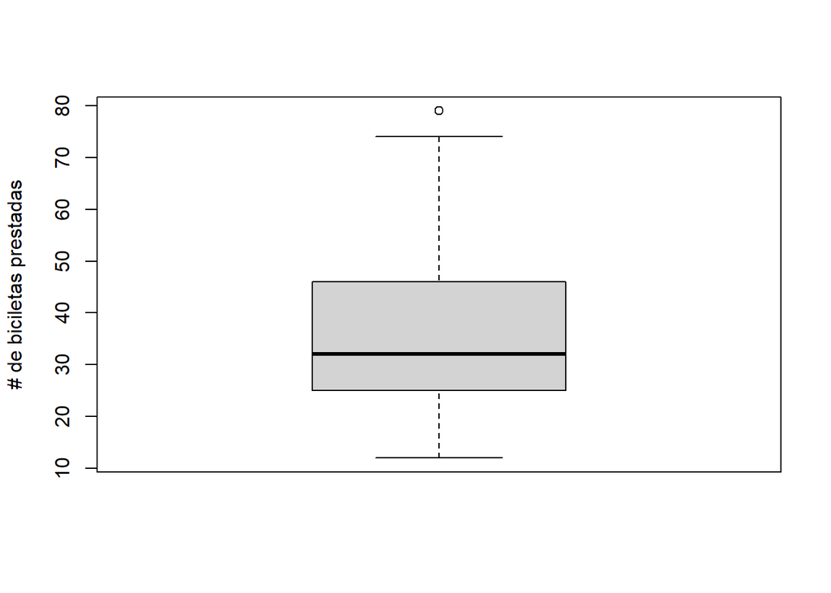

## Boxplot con variable de agrupación

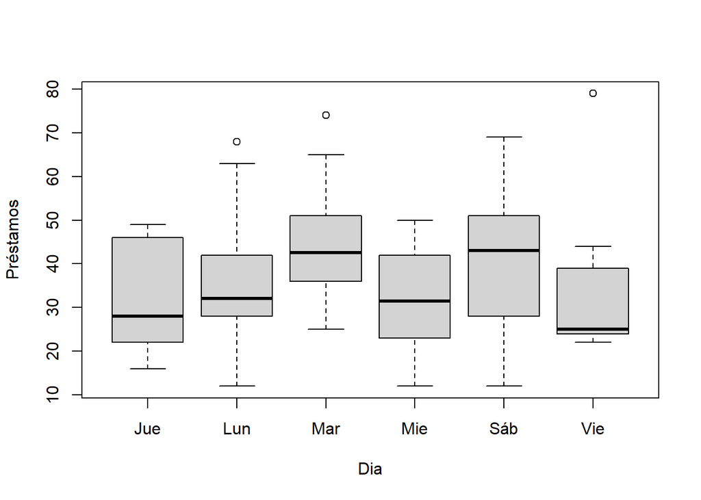

```r
data <- data.frame(Prestamos = x,
                   Dia = c(rep("Lun", 9),
                           rep(c("Mar","Mie","Jue"), each = 10),
                           rep("Vie", 9), rep("Sáb", 9))
                   )
boxplot(Prestamos ~ Dia, data = data, ylab = "Préstamos")
```

## Gráfico de Medias

# de Bicicletas promedio prestadas por día:

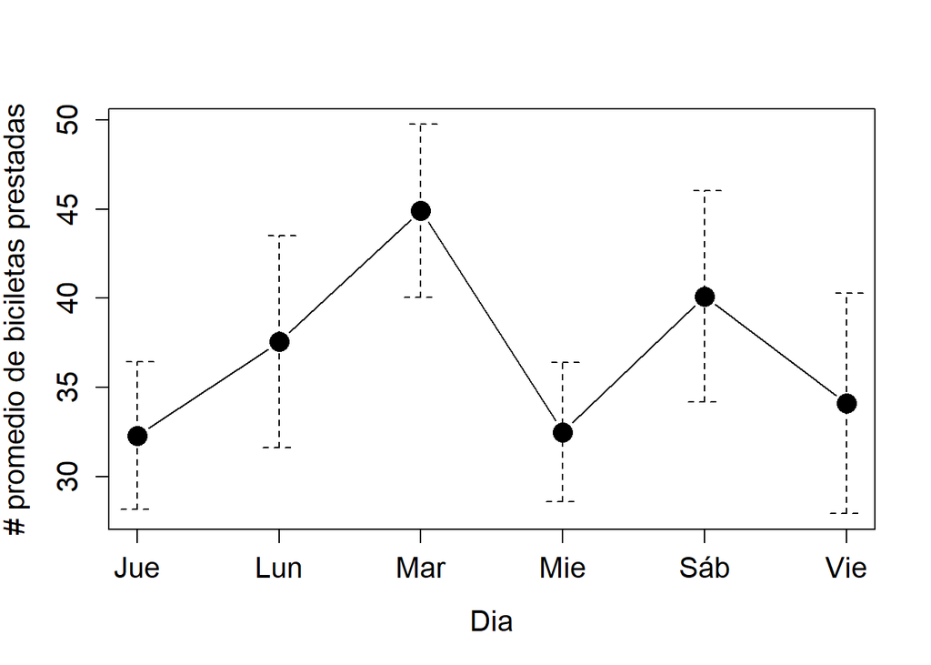

```r
library(RcmdrMisc)
par(cex.lab = 1.3, cex.axis = 1.3)
with(data, plotMeans(Prestamos, Dia, error.bars="se", main="",
  connect=TRUE, ylab = "# promedio de biciletas prestadas"))
```

Recuerde, el promedio señalado por el punto negro, y el error estándar señalado por las barras de error (las líneas punteadas) se calculan con los datos correspondientes a cada día. Por ejemplo, para el día *viernes*.

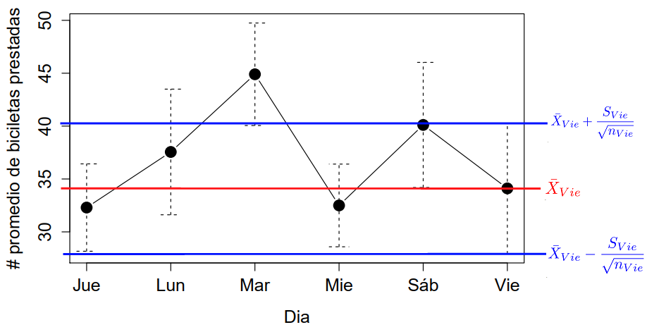

## Gráfico de Barras

- Permite graficar una variable numérica con **una** categórica.
- Permite representar graficamente tablas de frecuencia de variable categórica.
- Eje x: Variable categórica.
- Eje y: Variable numérica (o Frecuencia).

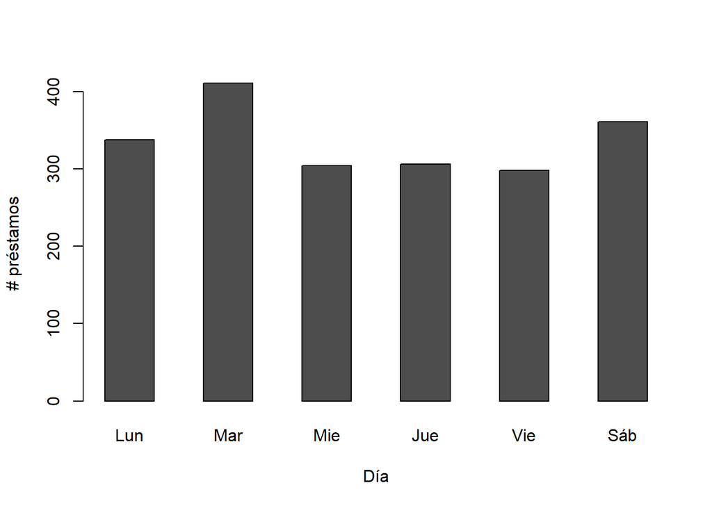

```r
resumen <- read.csv("frec_dia_hora.csv", header = T, row.names = "Dia")
data1 <- resumen[,-5]
data1 <- rowSums(data1)
barplot(t(data1), beside = TRUE, xlab = "Día", ylab = "# préstamos")
```

**Nota:** quitamos la columna 5 de manera arbitraria, para hacer una demostración de como eliminar columnas. Cuando hay este tipo de situaciones con valores `NA`, puede tener más relevancia quitar filas (recuerde el uso de `na.omit`).

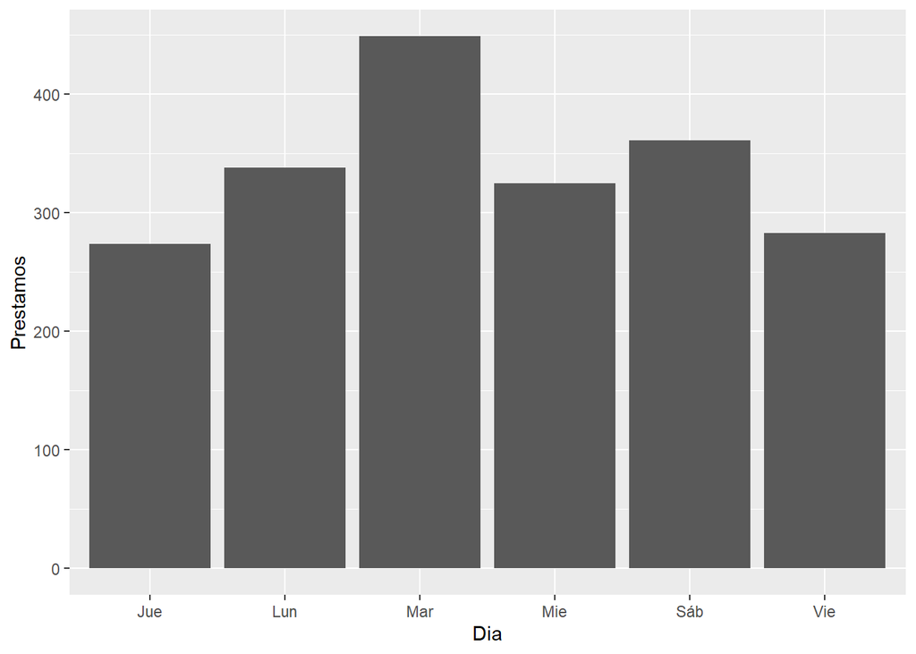

```r
ggplot(data = data, aes(x=Dia, y=Prestamos)) + geom_bar(stat="sum") +
  theme(legend.position = "none")
```

## Gráfico circular

- Permite representar graficamente tablas de frecuencia de variable categórica.
- Color: variable categórica
- Tamaño de la tajada: frecuencia.

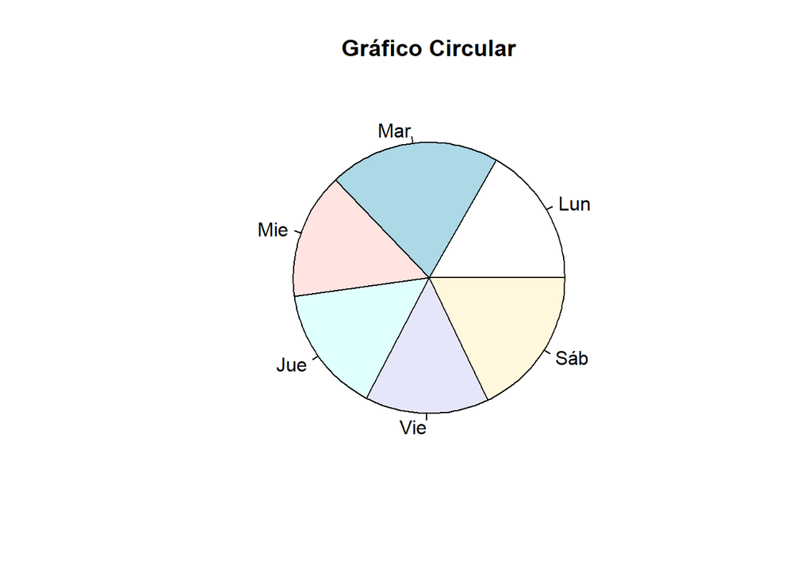

```r
lbls <- names(data1)
pie(data1, labels = lbls, main="Gráfico Circular")
```

## Gráfico de Barras comparativo (2 variables)

# de Bicicletas prestadas por día:

|  | Sem.1 | Sem.2 | Sem.3 | Sem.4 | Sem.5 | Sem.6 | Sem.7 | Sem.8 | Sem.9 | Sem.10 |
| --- | --- | --- | --- | --- | --- | --- | --- | --- | --- | --- |
| Lun | 68 | 63 | 42 | 27 |  | 30 | 36 | 28 | 32 | 12 |
| Mar | 65 | 43 | 25 | 74 | 38 | 51 | 36 | 42 | 28 | 47 |
| Mie | 12 | 32 | 49 | 38 | 21 | 42 | 27 | 31 | 50 | 23 |
| Jue | 22 | 43 | 27 | 49 | 16 | 28 | 23 | 19 | 46 | 49 |
| Vie | 79 | 27 | 22 | 23 |  | 24 | 25 | 44 | 30 | 24 |
| Sab | 31 | 28 | 25 | 45 |  | 12 | 57 | 51 | 43 | 69 |

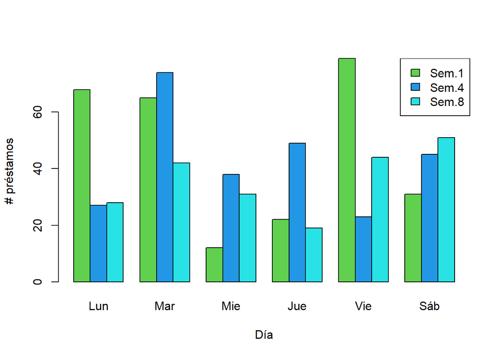

```r
data2 <- resumen[,c("Sem.1","Sem.4","Sem.8")]
barplot(t(data2), beside = T, col = 3:5, xlab = "Día", ylab = "# préstamos")
legend("topright", legend = colnames(data2), fil = 3:5)
```

## Histograma

- Permite representar graficamente tablas de frecuencia de variable numérica.
- Eje x: Variable numérica
- Eje y: Frecuencia.

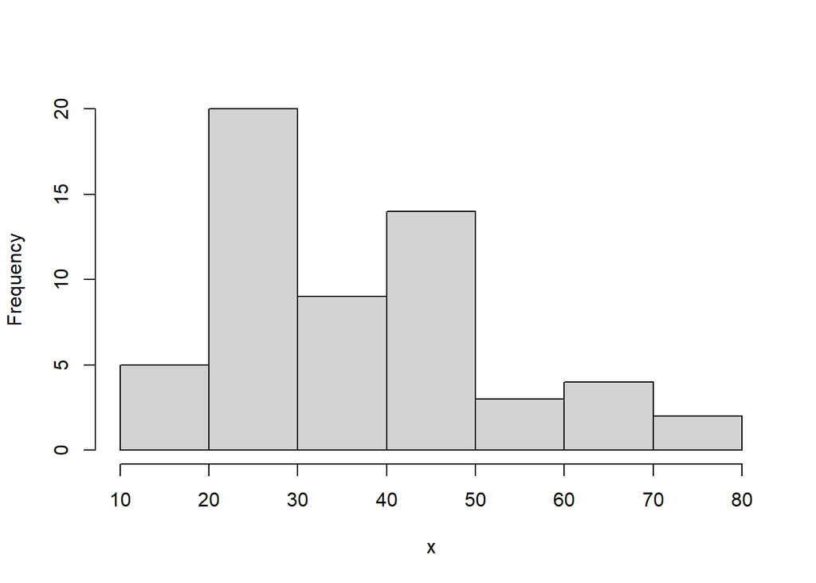

```r
h <- hist(x, main='')
```

Observe la siguiente tabla de frecuencias. ¿Qeé relación tiene con el histograma?

```r
library(fdth)
mi_tabla <- fdt(x = x, start = 10, end = 80, right = TRUE,
                h = 10)
summary(mi_tabla)
```

```
##  Class limits  f   rf rf(%) cf  cf(%)
##       (10,20]  5 0.09  8.77  5   8.77
##       (20,30] 20 0.35 35.09 25  43.86
##       (30,40]  9 0.16 15.79 34  59.65
##       (40,50] 14 0.25 24.56 48  84.21
##       (50,60]  3 0.05  5.26 51  89.47
##       (60,70]  4 0.07  7.02 55  96.49
##       (70,80]  2 0.04  3.51 57 100.00
```

## Polígono de Frecuencias (Ojiva)

- El gráfico es una serie de parejas ordendas unidas por rectas.
- Eje x: Variable aleatoria.
- Eje y: Frecuencia acumulada.

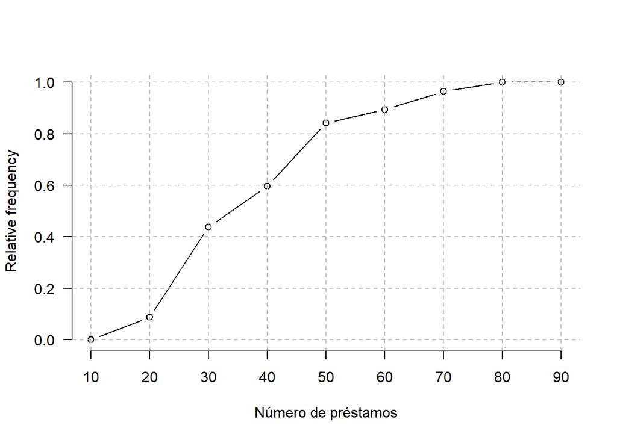

```
##   Número de préstamos    RCF
## 1                  10 0.0000
## 2                  20 0.0877
## 3                  30 0.4386
## 4                  40 0.5965
## 5                  50 0.8421
## 6                  60 0.8947
## 7                  70 0.9649
## 8                  80 1.0000
## 9                  90 1.0000
```

```r
# library(agricolae)
ogive.freq(h, xlab='Número de préstamos', ylab='Relative frequency')
```

## Diagrama de Pareto

- Se compone de un diagrama de barras, al cual se le superpone un gráfico de línea (polígono de frecuencia acumulada).
- Eje x: Variable categórica
- Eje y izquierdo: Frecuencia absoluta acumulada.
- Eje y derecho: Frecuencia relativa acumulada.

Grafiquemos uno de estos para las bicicletas

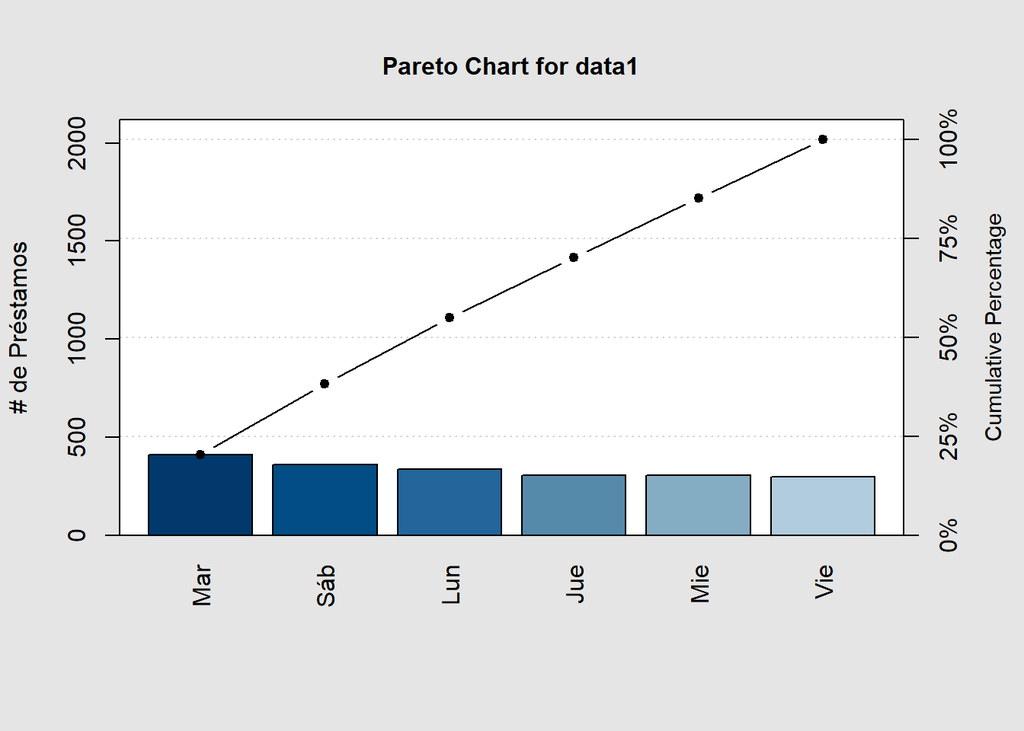

```
##
## Pareto chart analysis for data1
##        Frequency  Cum.Freq. Percentage Cum.Percent.
##   Mar  411.00000  411.00000   20.36670     20.36670
##   Sáb  361.00000  772.00000   17.88900     38.25570
##   Lun  338.00000 1110.00000   16.74926     55.00496
##   Jue  306.00000 1416.00000   15.16353     70.16848
##   Mie  304.00000 1720.00000   15.06442     85.23290
##   Vie  298.00000 2018.00000   14.76710    100.00000
```

```r
# library(qcc)
pareto.chart(data1, ylab='# de Préstamos')
```

# Ejemplo 2

## Ejemplo 2: datos *Iris*, de Edgar Anderson

La base de datos `iris`, disponible en R provee las medidas en centímetros de la longitud y ancho de los sépalos y de los pétalos de tres especies de flores.

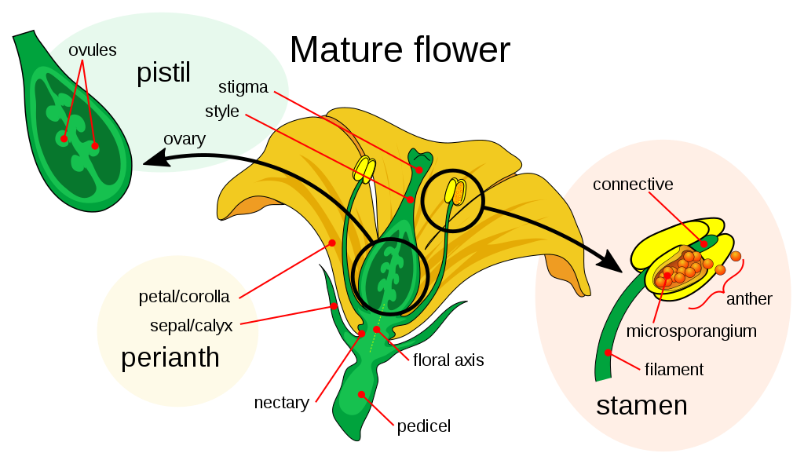

Extraido de [Wikipedia](https://en.wikipedia.org/wiki/Sepal)

Exploremos este conjunto de datos.